# HW 03 - Modelling

Due: 24 November, 16:00 UK time

## Data Load and preparation

```r
gss16<-read.csv("data/gss16.csv")
```

Selecting columns and removing missing observations:

```r
gss16_advfront <- gss16 %>%
  select(advfront, emailhr, educ, polviews, wrkstat) %>%
  drop_na()
```

Re-level the `advfront` variable such that it has two levels:

```r
gss16_advfront <- gss16_advfront %>%
  mutate(
    advfront = case_when(
      advfront == "Strongly agree" ~ "Agree",
      advfront == "Agree" ~ "Agree",
      TRUE ~ "Not agree"
    ),
    advfront = fct_relevel(advfront, "Not agree", "Agree")
  )
```

Combine the levels of the `polviews` variable (political views) such that levels that it has three levels: `"Conservative"` , `"Moderate"`, and `"Liberal"`

```r
gss16_advfront <- gss16_advfront %>%
  mutate(
    polviews = case_when(
      str_detect(polviews, "[Cc]onservative") ~ "Conservative",
      str_detect(polviews, "[Ll]iberal") ~ "Liberal",
      TRUE ~ polviews
    ),
    polviews = fct_relevel(polviews, "Conservative", "Moderate", "Liberal")
  )
```

Here are the first few rows of the cleaned and prepared data:

```r
gss16_advfront %>% head(n = 10)
```

```
##     advfront emailhr educ polviews          wrkstat
## 1      Agree      12   16 Moderate Working fulltime
## 2  Not agree       0   12  Liberal Working fulltime
## 3  Not agree       0   12 Moderate Working parttime
## 4      Agree       2   14  Liberal    Keeping house
## 5      Agree      40   14  Liberal Working fulltime
## 6      Agree      10   12  Liberal Working parttime
## 7      Agree       0   10 Moderate Temp not working
## 8      Agree       1   10  Liberal    Keeping house
## 9      Agree       2   13  Liberal Working fulltime
## 10     Agree      25   12  Liberal Working fulltime
```

## Exercise 1: Create a linear regression model

#### Exercise 1 (a)

```r
linear_fit <- linear_reg() %>%
  set_engine("lm") %>%
  fit(emailhr ~ educ, data = gss16_advfront)

linear_fit %>% tidy()
```

```
## # A tibble: 2 × 5
##   term        estimate std.error statistic       p.value
##   <chr>          <dbl>     <dbl>     <dbl>         <dbl>
## 1 (Intercept)   -2.76      1.66      -1.66 0.0970
## 2 educ           0.685     0.116      5.92 0.00000000413
```

Formula of the fitted model (roughly): $\widehat{emailhr} =$ -2.76 + 0.69 $\times \textrm{educ}$.

#### Exercise 1 (b)

```r
glance(linear_fit)
```

```
## # A tibble: 1 × 12
##   r.squared adj.r.squared sigma statistic       p.value    df logLik   AIC   BIC
##       <dbl>         <dbl> <dbl>     <dbl>         <dbl> <dbl>  <dbl> <dbl> <dbl>
## 1    0.0291        0.0283  10.9      35.1 0.00000000413     1 -4458. 8922. 8937.
## # ℹ 3 more variables: deviance <dbl>, df.residual <int>, nobs <int>
```

When the simple linear regression is considered for the `emailhr` variable, the model results in poor/moderate performance. In fact, the model R-squared value is very close to the zero (0.029), and this shows that these variables are not able to explain a large variation in the response variable – only 2.9% of the variation in `emailhr` is explained by the model.

To examine if the linear model assumptions are satisfied we need to create a diagnostic plot, or “residual by fitted” plot.

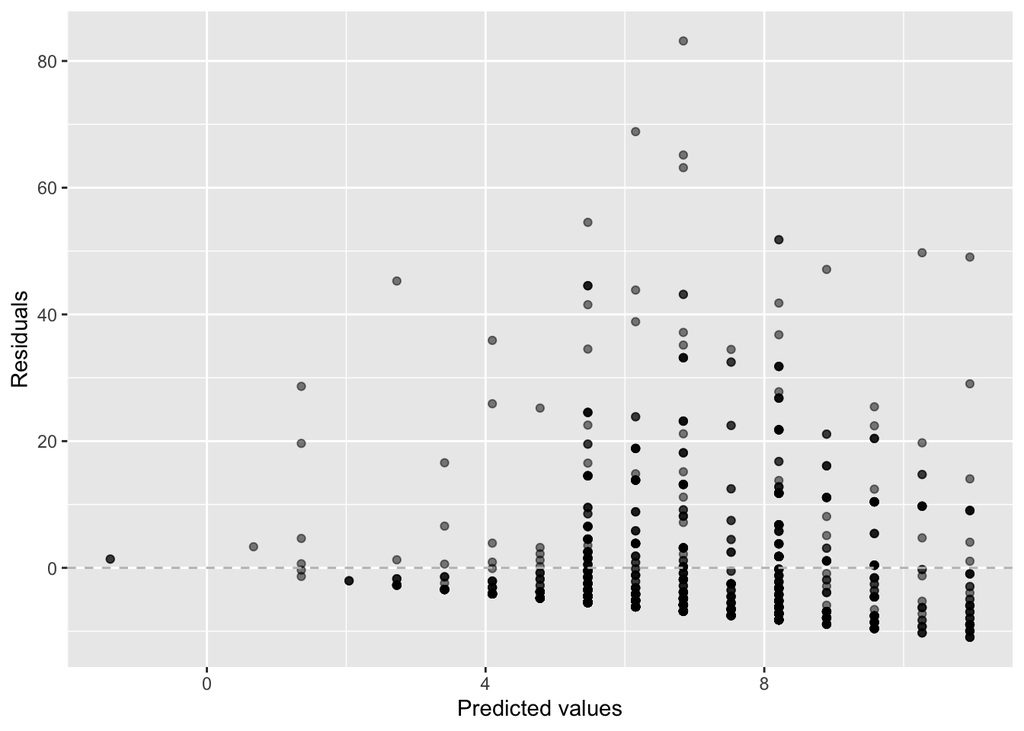

```r
em_ed_ft_fit_aug <- augment(linear_fit$fit)
ggplot(em_ed_ft_fit_aug, mapping = aes(x = .fitted, y = .resid)) +
  geom_point(alpha = 0.5) +
  geom_hline(yintercept = 0, color = "gray", lty = "dashed") +
  labs(x = "Predicted values", y = "Residuals")
```

By examining the residual by fitted plot, we see that the residuals do not satisty the assumption of the linear model, as they display a “fan shape”, i.e. the variance of the residuals appears to be larger for larger predicted values.

**Note: creating the following scatterplot does not allow us to assess if the model assumptions are satisfied**, and should not receive points.

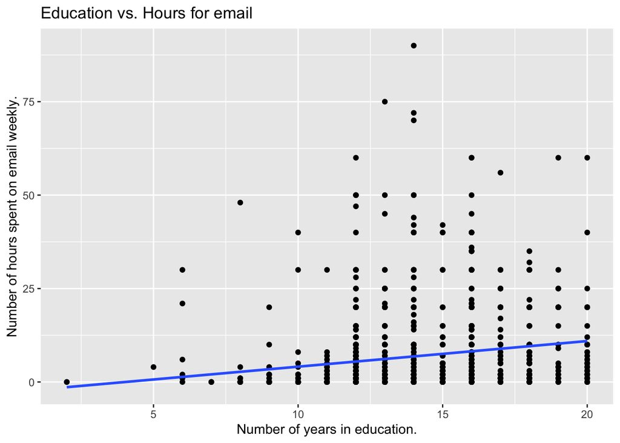

```r
ggplot(data = gss16_advfront, mapping = aes(x = educ, y = emailhr)) +
  geom_point() +
  geom_smooth(method = "lm", se = FALSE, formula = "y ~ x") +
  labs(
    x = "Number of years in education.",
    y = "Number of hours spent on email weekly.",
    title = "Education vs. Hours for email"
    )
```

Nevertheless from this scatterplot we can deduce that something is off (the increasing variance of the residual around the fitted line).

It is possible to make the correct statement that there is a fan-shape pattern in the residuals from examining this plot, so points for the “fan-shape comment” should be awarded in this case.

## Exercise 2: Create a workflow to fit a model

```r
set.seed(1234)
gss16_split <- initial_split(gss16_advfront)
gss16_train <- training(gss16_split)
gss16_test  <- testing(gss16_split)
```

#### Exercise 2 (a)

Recipe

```r
gss16_rec_1 <- recipe(advfront ~ educ, data = gss16_train)
# -- these are valid steps, that could be added with %>% --
# -- (but not necessarily required by the question)      --
# step_dummy(all_nominal(), -all_outcomes())
# step_zv(all_predictors())
```

Model

```r
gss16_mod_1 <- logistic_reg() %>%
  set_engine("glm")
```

Workflow

```r
gss16_wflow_1 <- workflow() %>%
  add_model(gss16_mod_1) %>%
  add_recipe(gss16_rec_1)
```

#### Exercise 2 (b)

A logistic regression is the appropriate model to use here because the response variable is binary (agree vs not agree).

#### Exercise 2 (c)

```r
gss16_fit_1 <- gss16_wflow_1 %>%
  fit(gss16_train)
tidy(gss16_fit_1)
```

```
## # A tibble: 2 × 5
##   term        estimate std.error statistic   p.value
##   <chr>          <dbl>     <dbl>     <dbl>     <dbl>
## 1 (Intercept)   -0.375    0.485     -0.773 0.439
## 2 educ           0.150    0.0356     4.21  0.0000252
```

The fitted model results in a coefficient of 0.15 for education, suggesting that the probability for agreeing with the statement increases on average for a participant with a larger number of years in education.

*Note the interpretation of the coefficient was not requested by the exercise.*

## Exercise 3: Logistic regression with single predictor

#### Exercise 3 (a)

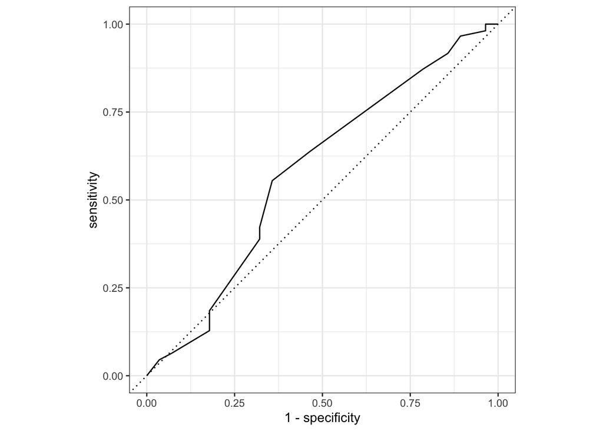

```r
# Model 1
gss16_test_pred_1 <- predict(gss16_fit_1, new_data = gss16_test, type = "prob") %>%
  bind_cols(gss16_test %>% select(advfront))

gss16_test_pred_1 %>%
  roc_curve(truth = advfront, .pred_Agree, event_level = "second") %>%
  autoplot()
```

```r
gss16_test_pred_1 %>%
  roc_auc(truth = advfront, .pred_Agree, event_level = "second")
```

```
## # A tibble: 1 × 3
##   .metric .estimator .estimate
##   <chr>   <chr>          <dbl>
## 1 roc_auc binary         0.581
```

This model has a AUC (areal under the curve) of 0.58. *Note, calculating the AUC was not required as part of this exercise, but it will be useful for the last question.*

**If option `event_level = 'second'` is not specified, the ROC curve plot is the “reverse” ROC curve**:

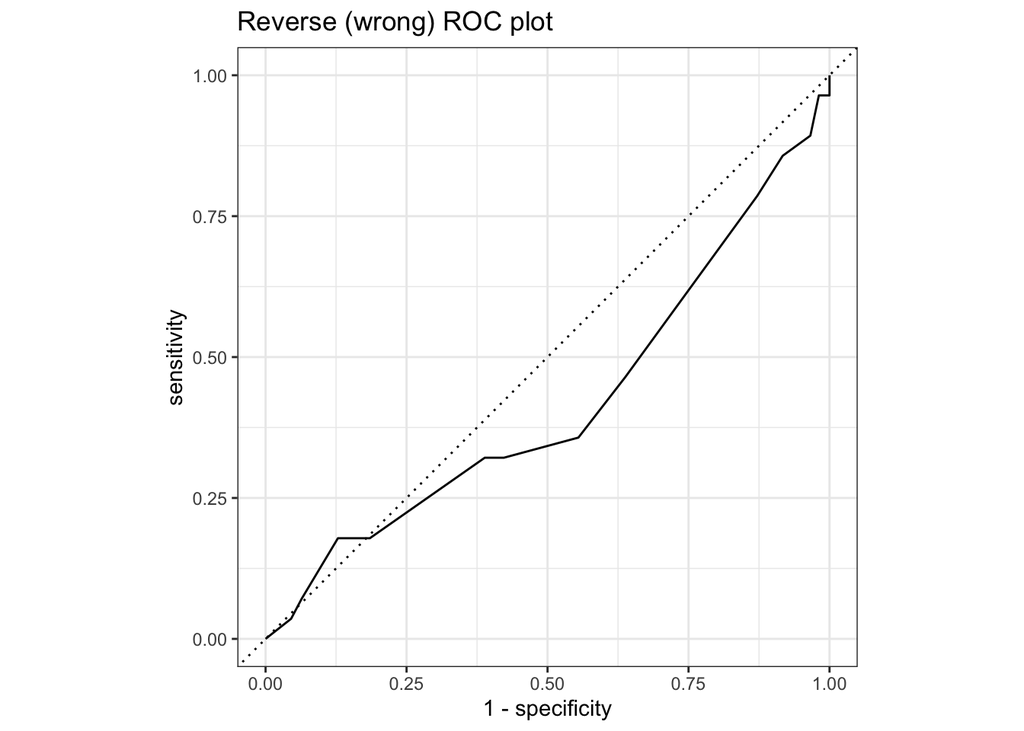

```r
gss16_test_pred_1 %>%
  roc_curve(truth = advfront, .pred_Agree) %>%
  autoplot() + ggtitle("Reverse (wrong) ROC plot")
```

#### Exercise 3 (b)

```r
threshold <- 0.83

table_pred <- gss16_test_pred_1 %>%
  mutate(
    advfront_pred = if_else(.pred_Agree >= threshold, "Predicted to agree", "Predicted to disagree"),
    advfront = if_else(advfront == "Agree", "Agree", "Disagree")
  ) %>%
  count(advfront_pred, advfront) %>%
  pivot_wider(names_from = advfront, values_from = n)
table_pred
```

```
## # A tibble: 2 × 3
##   advfront_pred         Agree Disagree
##   <chr>                 <int>    <int>
## 1 Predicted to agree      147       10
## 2 Predicted to disagree   118       18
```

This means that

- TP = 147; FP = 10
- FN = 118, TN = 18

Sensitivity is the probability of “predicting to agree” for a participant who agrees, and it’s computed as TP / (TP + FN), so 0.55.

Specificity is the probability of “predicting to disagree” for a participant who disagree, and it’s computed as TN / (FP + TN), so 0.64.

Alternatively, there are `sensitivity` and `specificity` functions in the `caret` package. Other functions `sens` and `spec` are available from other packages. This is not the recommended solution, but it’s accepted.

```r
gss16_test_labels_085 <- gss16_test_pred_1 %>%
  mutate(
    advfront_pred = factor(if_else(.pred_Agree >= threshold, "Agree", "Disagree")),
    advfront = factor(if_else(advfront == "Agree", "Agree", "Disagree"))
  )

library(caret)

sensitivity(data = gss16_test_labels_085$advfront_pred,
            reference = gss16_test_labels_085$advfront)
```

```
## [1] 0.554717
```

```r
specificity(data = gss16_test_labels_085$advfront_pred,
            reference = gss16_test_labels_085$advfront)
```

```
## [1] 0.6428571
```

## Exercise 4: Logistic regression modelling and interpretation

#### Exercise 4 (a)

Model workflow steps:

```r
gss16_rec_2 <- recipe(advfront ~ educ + wrkstat + polviews + emailhr,
                      data = gss16_train) %>%
  step_dummy(all_nominal(), -all_outcomes())
  # step_dummy(all_nominal_predictors()) # this also works
  # step_zv(all_predictors()) # also valid step

gss16_mod_2 <- logistic_reg() %>%
  set_engine("glm")

gss16_wflow_2 <- workflow() %>%
  add_model(gss16_mod_2) %>%
  add_recipe(gss16_rec_2)
```

Again, a logistic regression is used because the outcome is binary.

#### Exercise 4 (b)

Fitting the model to the training data:

```r
gss16_fit_2 <- gss16_wflow_2 %>%
  fit(gss16_train)
tidy(gss16_fit_2)
```

```
## # A tibble: 12 × 5
##    term                     estimate std.error statistic  p.value
##    <chr>                       <dbl>     <dbl>     <dbl>    <dbl>
##  1 (Intercept)              -0.936      0.547     -1.71  0.0869
##  2 educ                      0.134      0.0376     3.56  0.000374
##  3 emailhr                   0.00594    0.0100     0.592 0.554
##  4 wrkstat_Other            -0.117      0.593     -0.198 0.843
##  5 wrkstat_Retired           0.445      0.336      1.33  0.185
##  6 wrkstat_School            1.61       1.07       1.51  0.131
##  7 wrkstat_Temp.not.working  0.101      0.627      0.161 0.872
##  8 wrkstat_Unempl..laid.off  0.441      0.519      0.849 0.396
##  9 wrkstat_Working.fulltime  0.561      0.298      1.88  0.0595
## 10 wrkstat_Working.parttime  0.898      0.401      2.24  0.0252
## 11 polviews_Moderate         0.350      0.218      1.61  0.108
## 12 polviews_Liberal          0.462      0.248      1.87  0.0617
```

Predicting the new model on the test data:

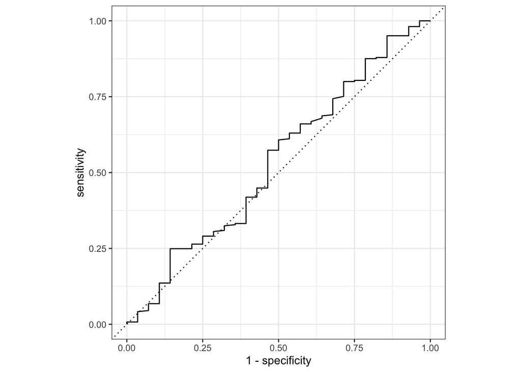

```r
gss16_test_pred_2 <- predict(gss16_fit_2,
                             new_data = gss16_test, type = "prob") %>%
  bind_cols(gss16_test %>% select(advfront))

gss16_test_pred_2 %>%
  roc_curve(truth = advfront, .pred_Agree, event_level = "second") %>%
  autoplot()
```

```r
gss16_test_pred_2 %>%
  roc_auc(truth = advfront, .pred_Agree, event_level = "second")
```

```
## # A tibble: 1 × 3
##   .metric .estimator .estimate
##   <chr>   <chr>          <dbl>
## 1 roc_auc binary         0.535
```

```r
AUC2 <- gss16_test_pred_2 %>%
  roc_auc(truth = advfront, .pred_Agree, event_level = "second") %>%
  pull(.estimate)
```

The area under the ROC curve for the second model (0.5345013) is moderately less than the first model (0.5807278).

#### Exercise 4 (c)

Model 1 has better AUC (area under ROC curve) than model 2. Moreover, model 1 has fewer variables, which is generally preferred due to reduced model complexity (Occam’s razor), run time, and better generalizability, so even if they have comparable preformance, this model should be favoured.